# MeSH Analysis

Tami L Crawford

4/18/2018

# 1 Overview

Generate some data based on MeSH terms.

Report parameters:

- Start year: 2012
- End year: 2016

# 2 Load data

For this analysis, this data is used

- *pilot_grant_status* - contains person identifiers (personid, emailaddr, name) allow with grant status (funded, unfunded, nonapplicant). If funded, grant start date.
- *author_pubs* - contains the publications for all applicants (funded and unfunded), including pmid, title
- *mesh* - contains the major and minor subject areas, mesh description and mesh group for all publications

```r
library(profilesrnsexplorer)
library(tidyverse)
data(mesh)
data(pilot_grant_status)
data(author_pubs)
```

## 2.1 Select subset of people to include (Part 1)

We only want to consider the grant applicants.

Within those grant applicants, we will divide into groups based on grant status (funded/unfunded).

The sampling method will use these groups to select equal numbers from each group.

```r
applicants <- pilot_grant_status %>%
  filter(grant_status %in% c("funded", "unfunded"))

knitr::kable(applicants %>%
  count(grant_status, sort = TRUE))
```

| grant_status | n |
| --- | --- |
| unfunded | 110 |
| funded | 76 |

## 2.2 Group by number of publications

Select only publications for the selected participants, for the years of interest.

NOTE: publications are by author, so if there are multiple authors in ProfilesRNS, there will be multiple rows in the publications table, one for each person.

```r
pubs <- applicants %>%
  left_join(author_pubs, by=c("personid","personid")) %>%
  filter(year %in% params$start_year:params$end_year)

pubcounts <- pubs %>%
  count(displayname, personid, grant_status, sort = TRUE) %>%
  rename(num_pubs = n)

knitr::kable(head(pubcounts))
```

| displayname | personid | grant_status | num_pubs |
| --- | --- | --- | --- |
| Rodney J. Schlosser | 2970 | funded | 103 |
| Diane L. Kamen | 2416 | funded | 66 |
| Mulugeta Gebreselassie Gebregziabher | 2190 | unfunded | 65 |
| David J. Taber | 3643 | unfunded | 63 |
| Graham Walter Warren | 3660 | unfunded | 56 |
| Raymond D. Turner | 2862 | unfunded | 56 |

There are 3045 publications for the selected people and years. Note: each publication appears once for each author in the selected set, so if the number of unique publications is less.

## 2.3 Create sampled data

Using replace on sample size because otherwise the groups are too small. The data is sampled taking equal numbers from each subgroup.

```r
breaks <- quantile(pubcounts$num_pubs, probs=seq(0, 1, by=0.25), na.rm=TRUE)

pubcounts$quartile <- with(pubcounts,
      cut(num_pubs, breaks = breaks, include.lowest = TRUE))

# 5 for each group gives 20 each of unfunded/funded
sample_size <- 5

participants <- sample_n(pubcounts %>%
      group_by(grant_status, quartile), sample_size, replace = TRUE)

knitr::kable(participants)
```

| displayname | personid | grant_status | num_pubs | quartile |
| --- | --- | --- | --- | --- |
| Paula S. Ramos | 3527 | funded | 2 | [1,7] |
| Eric Stafford Zollars | 4324 | funded | 3 | [1,7] |
| Naohiro Yamaguchi | 2736 | funded | 6 | [1,7] |
| Kimberly E McHugh | 3959 | funded | 3 | [1,7] |
| Robert Neal Axon | 1796 | funded | 7 | [1,7] |
| Adam J. Smolka | 3058 | funded | 9 | (7,12.5] |
| Christine A Holmstedt | 1924 | funded | 8 | (7,12.5] |
| Christine M Carr | 1938 | funded | 9 | (7,12.5] |
| Elizabeth J. Santa Ana | 2115 | funded | 8 | (7,12.5] |
| Eric Carter Bartee | 3650 | funded | 8 | (7,12.5] |
| Dieter Georg Haemmerich | 2244 | funded | 13 | (12.5,21] |
| Maria V. Spampinato | 3072 | funded | 21 | (12.5,21] |
| Stanley Hoffman | 2318 | funded | 15 | (12.5,21] |
| Leonardo Fator Gouvea Bonilha | 3694 | funded | 14 | (12.5,21] |
| Leonardo Fator Gouvea Bonilha | 3694 | funded | 14 | (12.5,21] |
| Carla Kmett Danielson | 2037 | funded | 30 | (21,103] |
| John W McGillicuddy | 2636 | funded | 35 | (21,103] |
| Richard R. Drake | 3543 | funded | 43 | (21,103] |
| Rodney J. Schlosser | 2970 | funded | 103 | (21,103] |
| Edward C. Jauch | 2105 | funded | 49 | (21,103] |
| Mae Millicent Winfrey Peterseim | 2813 | unfunded | 3 | [1,7] |
| Jennifer S. Isaacs | 2352 | unfunded | 6 | [1,7] |
| George Hamilton Baker | 1811 | unfunded | 1 | [1,7] |
| Cristina M Lopez | 3630 | unfunded | 7 | [1,7] |
| Aiping Bai | 1806 | unfunded | 7 | [1,7] |
| Whitney S Graybill | 3248 | unfunded | 9 | (7,12.5] |
| Jacqueline F Mcginty | 2638 | unfunded | 10 | (7,12.5] |
| Vivienne Jiangwen Zhu | 4851 | unfunded | 11 | (7,12.5] |
| Gonzalo J. Revuelta | 2205 | unfunded | 9 | (7,12.5] |
| Suniti Misra | 2674 | unfunded | 12 | (7,12.5] |
| Hong Yu | 3574 | unfunded | 16 | (12.5,21] |
| Azizul Haque | 2263 | unfunded | 21 | (12.5,21] |
| Ramin M. Eskandari | 4255 | unfunded | 20 | (12.5,21] |
| Sundaravadivel Balasubramanian | 3114 | unfunded | 13 | (12.5,21] |
| Richard P. Visconti | 3220 | unfunded | 14 | (12.5,21] |
| Carol L. Wagner | 3229 | unfunded | 31 | (21,103] |
| Kenneth D. Tew | 3147 | unfunded | 25 | (21,103] |
| Carol L. Wagner | 3229 | unfunded | 31 | (21,103] |
| Abby Swanson Kazley | 3126 | unfunded | 28 | (21,103] |
| Marc Ivor Chimowitz | 2663 | unfunded | 37 | (21,103] |

## 2.4 Select pubs for those applicants

```r
sampled_pubs <- participants %>%
  left_join(pubs, by=c("displayname","personid","grant_status"))

knitr::kable(head(sampled_pubs %>%
                    select(displayname,
                           num_pubs,
                           grant_status,
                           quartile,
                           author,
                           pubdate
                           )))
```

| displayname | num_pubs | grant_status | quartile | author | pubdate |
| --- | --- | --- | --- | --- | --- |
| Paula S. Ramos | 2 | funded | [1,7] | https://profiles.healthsciencessc.org/profile/109104 | 2013-05-01 |
| Paula S. Ramos | 2 | funded | [1,7] | https://profiles.healthsciencessc.org/profile/109104 | 2012-03-29 |
| Eric Stafford Zollars | 3 | funded | [1,7] | https://profiles.healthsciencessc.org/profile/2865164 | 2016-08-30 |
| Eric Stafford Zollars | 3 | funded | [1,7] | https://profiles.healthsciencessc.org/profile/2865164 | 2015-10-24 |
| Eric Stafford Zollars | 3 | funded | [1,7] | https://profiles.healthsciencessc.org/profile/2865164 | 2015-06-18 |
| Naohiro Yamaguchi | 6 | funded | [1,7] | https://profiles.healthsciencessc.org/profile/108312 | 2016-08-24 |

## 2.5 Identify MeSH terms for these publications

```r
mesh_pubs <- sampled_pubs %>%
  left_join(mesh, by=c("pmid","infoResource")) %>%
  select(personid, displayname, grant_status, quartile, pmid, bs_or_c, topic, minorTopic,
         meshDescriptor, meshGroup)
#print(colnames(mesh_pubs))
knitr::kable(head(mesh_pubs))
```

| personid | displayname | grant_status | quartile | pmid | bs_or_c | topic | minorTopic | meshDescriptor | meshGroup |
| --- | --- | --- | --- | --- | --- | --- | --- | --- | --- |
| 3527 | Paula S. Ramos | funded | [1,7] | 23637325 | BS | African Continental Ancestry Group; Genetic Predisposition to Disease; Lupus Erythematosus, Systemic | Adult; Alleles; Genetic Association Studies; Genetic Loci; Genotype; Glutathione Reductase; Haplotypes; Humans; NADH Dehydrogenase; Nitric Oxide Synthase Type I; Polymorphism, Single Nucleotide | D006801 | Living Beings |
| 3527 | Paula S. Ramos | funded | [1,7] | 23637325 | BS | African Continental Ancestry Group; Genetic Predisposition to Disease; Lupus Erythematosus, Systemic | Adult; Alleles; Genetic Association Studies; Genetic Loci; Genotype; Glutathione Reductase; Haplotypes; Humans; NADH Dehydrogenase; Nitric Oxide Synthase Type I; Polymorphism, Single Nucleotide | D000328 | Living Beings |
| 3527 | Paula S. Ramos | funded | [1,7] | 23637325 | BS | African Continental Ancestry Group; Genetic Predisposition to Disease; Lupus Erythematosus, Systemic | Adult; Alleles; Genetic Association Studies; Genetic Loci; Genotype; Glutathione Reductase; Haplotypes; Humans; NADH Dehydrogenase; Nitric Oxide Synthase Type I; Polymorphism, Single Nucleotide | D006239 | Physiology |
| 3527 | Paula S. Ramos | funded | [1,7] | 23637325 | BS | African Continental Ancestry Group; Genetic Predisposition to Disease; Lupus Erythematosus, Systemic | Adult; Alleles; Genetic Association Studies; Genetic Loci; Genotype; Glutathione Reductase; Haplotypes; Humans; NADH Dehydrogenase; Nitric Oxide Synthase Type I; Polymorphism, Single Nucleotide | D056426 | Genes & Molecular Sequences |
| 3527 | Paula S. Ramos | funded | [1,7] | 23637325 | BS | African Continental Ancestry Group; Genetic Predisposition to Disease; Lupus Erythematosus, Systemic | Adult; Alleles; Genetic Association Studies; Genetic Loci; Genotype; Glutathione Reductase; Haplotypes; Humans; NADH Dehydrogenase; Nitric Oxide Synthase Type I; Polymorphism, Single Nucleotide | D020022 | Physiology |
| 3527 | Paula S. Ramos | funded | [1,7] | 23637325 | BS | African Continental Ancestry Group; Genetic Predisposition to Disease; Lupus Erythematosus, Systemic | Adult; Alleles; Genetic Association Studies; Genetic Loci; Genotype; Glutathione Reductase; Haplotypes; Humans; NADH Dehydrogenase; Nitric Oxide Synthase Type I; Polymorphism, Single Nucleotide | D009245 | Chemicals & Drugs |

## 2.6 Get the groups

```r
by_mesh_group <- mesh_pubs %>%
  count(grant_status, meshGroup, sort = TRUE)
knitr::kable(head(by_mesh_group))
```

[output not shown]

## 2.7 Plot

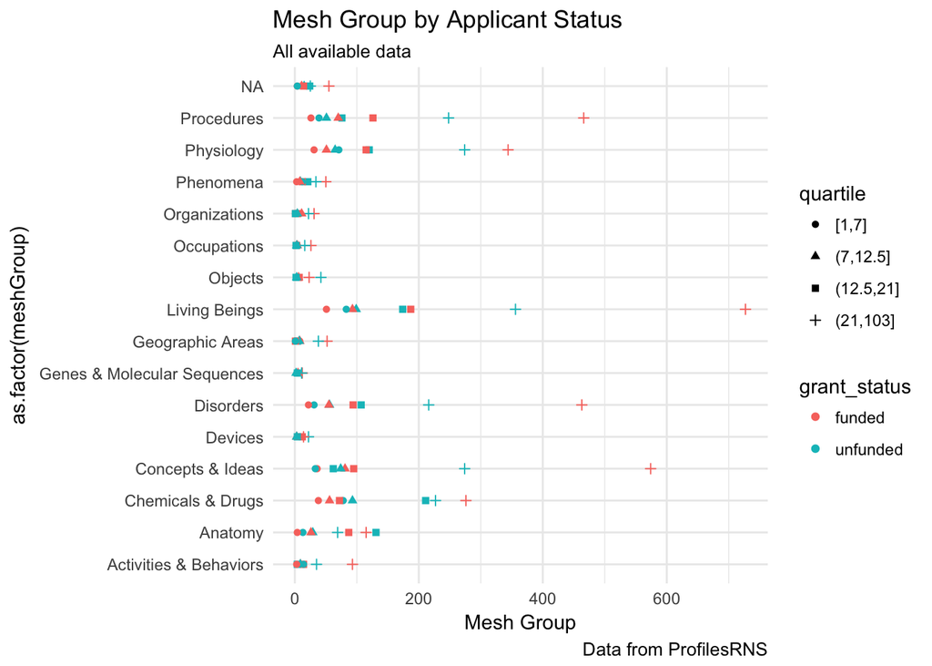

```r
ggplot(by_mesh_group) +
  theme_minimal() +
  #shape should be quartile?
  geom_point(aes(x=as.factor(meshGroup),
                 y = n,
                 color = grant_status,
                 shape = quartile)) +
  ylab("Mesh Group") +
  coord_flip() +
  ggtitle("Mesh Group by Applicant Status",
          subtitle = "All available data") +
  labs(caption = "Data from ProfilesRNS")
```